# Nuuk Fjord: Drivers of shrub abundance - development of beta-binomial mixture model

Jonathan von Oppen

05/05/2020

## Dependencies

Packages included:

- tidyverse - for convenient code flow, data wrangling and plotting
- rjags & R2jags - to link JAGS and R
- skimr - for data summary
- Rmarkdown - to produce this neat little documentation

```r
# load pacman package from the repository, if you do not already have it
if (!require('pacman')) install.packages('pacman', repos="https://cloud.r-project.org")
pacman::p_load(tidyverse, # set of packages for data manipulation, exploration and visualisation
               rjags,     # to link JAGS and R
               R2jags,    # to link JAGS and R
               skimr,     # for quick dataframe inspection
               rmarkdown) # for R Markdown formatting
```

## Import data

Analyses conducted on fusion table at **plot group $\times$ taxon level**: 621 observations for 57 variables

```r
env_cov_bio <- read.csv("../../data/nuuk_env_cover_plotgroups.csv", header = T)
```

```r
skim(env_cov_bio)
```

Data summary

| Name | env_cov_bio |
| --- | --- |
| Number of rows | 621 |
| Number of columns | 57 |
| _______________________ |  |
| Column type frequency: |  |
| factor | 3 |
| numeric | 54 |
| ________________________ |  |
| Group variables | None |

**Variable type: factor**

| skim_variable | n_missing | complete_rate | ordered | n_unique | top_counts |
| --- | --- | --- | --- | --- | --- |
| site_alt_plotgroup_id | 0 | 1 | FALSE | 69 | 1_1: 9, 1_1: 9, 1_1: 9, 1_2: 9 |
| site_alt_id | 0 | 1 | FALSE | 23 | 1_1: 27, 1_2: 27, 1_2: 27, 2_1: 27 |
| taxon | 0 | 1 | FALSE | 9 | Bet: 69, Cas: 69, Emp: 69, Phy: 69 |

**Variable type: numeric**

| skim_variable | n_missing | complete_rate | mean | sd | p0 | p25 | p50 | p75 | p100 | hist |
| --- | --- | --- | --- | --- | --- | --- | --- | --- | --- | --- |
| x | 0 | 1 | 510530.76 | 28727.18 | 460602.86 | 476772.63 | 522884.61 | 542653.40 | 546029.50 | ▇▁▇▇▇ |
| y | 0 | 1 | 7158467.09 | 14782.51 | 7123238.42 | 7152886.56 | 7158927.84 | 7168345.96 | 7174367.78 | ▂▁▂▅▇ |
| long | 0 | 1 | -50.78 | 0.60 | -51.81 | -51.48 | -50.52 | -50.11 | -50.04 | ▇▁▇▇▇ |
| lat | 0 | 1 | 64.55 | 0.13 | 64.23 | 64.50 | 64.55 | 64.64 | 64.69 | ▂▁▂▅▇ |
| site | 0 | 1 | 3.39 | 1.34 | 1.00 | 2.00 | 4.00 | 5.00 | 5.00 | ▃▃▇▇▇ |
| alt | 0 | 1 | 204.35 | 153.57 | 20.00 | 100.00 | 200.00 | 300.00 | 500.00 | ▇▃▂▂▂ |
| inclin_down | 0 | 1 | 21.65 | 8.35 | 6.83 | 15.67 | 20.67 | 26.50 | 40.33 | ▅▆▇▃▃ |
| inclin_dir | 0 | 1 | 206.78 | 76.87 | 32.33 | 165.83 | 208.83 | 268.83 | 325.50 | ▃▂▇▆▇ |
| year | 0 | 1 | 2011.83 | 0.82 | 2011.00 | 2011.00 | 2012.00 | 2013.00 | 2013.00 | ▇▁▆▁▅ |
| x_stere | 0 | 1 | -282129.82 | 30091.02 | -336483.20 | -316954.77 | -268787.18 | -249619.08 | -246094.71 | ▃▃▇▇▇ |
| y_stere | 0 | 1 | -2786936.96 | 13429.81 | -2817568.22 | -2791167.95 | -2789436.09 | -2778483.45 | -2770162.30 | ▃▁▇▃▇ |
| tempjja_ts_5 | 0 | 1 | 10.92 | 1.47 | 7.24 | 10.28 | 11.36 | 11.86 | 13.30 | ▂▂▃▇▃ |
| tempmax_ts_5 | 0 | 1 | 12.25 | 1.55 | 8.40 | 11.70 | 12.63 | 13.36 | 14.72 | ▂▂▃▇▅ |
| tempjja_ts_10 | 0 | 1 | 10.68 | 1.41 | 7.11 | 9.95 | 11.11 | 11.58 | 12.93 | ▂▂▃▇▃ |
| tempmax_ts_10 | 0 | 1 | 11.73 | 1.41 | 8.16 | 11.02 | 12.13 | 12.67 | 13.96 | ▂▂▃▇▅ |
| tempjja_ts_15 | 0 | 1 | 10.50 | 1.38 | 6.99 | 9.82 | 10.88 | 11.43 | 12.69 | ▂▂▃▇▅ |
| tempmax_ts_15 | 0 | 1 | 11.55 | 1.41 | 7.98 | 10.85 | 11.96 | 12.52 | 13.74 | ▂▂▃▇▅ |
| tempjja_ts_20 | 0 | 1 | 10.11 | 1.35 | 6.66 | 9.49 | 10.51 | 11.00 | 12.31 | ▂▁▃▇▃ |
| tempmax_ts_20 | 0 | 1 | 11.31 | 1.42 | 7.73 | 10.60 | 11.73 | 12.27 | 13.51 | ▂▂▃▇▅ |
| tempjja_ts_30 | 0 | 1 | 9.89 | 1.36 | 6.43 | 9.25 | 10.24 | 10.81 | 12.04 | ▂▂▃▇▅ |
| tempmax_ts_30 | 0 | 1 | 11.26 | 1.41 | 7.72 | 10.54 | 11.69 | 12.19 | 13.48 | ▂▂▃▇▅ |
| tempmin_ts_5 | 0 | 1 | -15.50 | 2.31 | -19.09 | -16.91 | -15.97 | -14.11 | -10.59 | ▃▇▃▂▂ |
| tempmin_ts_10 | 0 | 1 | -16.65 | 2.41 | -20.37 | -18.23 | -17.42 | -14.71 | -11.66 | ▃▇▃▂▂ |
| tempmin_ts_15 | 0 | 1 | -17.28 | 2.50 | -21.17 | -18.97 | -17.92 | -15.31 | -12.08 | ▅▇▃▂▂ |
| tempmin_ts_20 | 0 | 1 | -18.24 | 2.42 | -21.93 | -19.85 | -19.01 | -16.40 | -13.13 | ▃▇▃▂▂ |
| tempmin_ts_30 | 0 | 1 | -18.97 | 2.47 | -22.86 | -20.69 | -19.57 | -17.01 | -13.88 | ▅▇▃▃▃ |
| tempcont_ts_5 | 0 | 1 | 27.75 | 2.04 | 22.63 | 27.56 | 28.27 | 28.86 | 30.25 | ▂▁▁▇▆ |
| tempcont_ts_10 | 0 | 1 | 28.38 | 2.08 | 23.17 | 27.48 | 29.25 | 29.72 | 30.18 | ▂▁▁▂▇ |
| tempcont_ts_15 | 0 | 1 | 28.83 | 2.18 | 23.35 | 27.89 | 29.74 | 30.28 | 30.69 | ▂▁▁▁▇ |
| tempcont_ts_20 | 0 | 1 | 29.55 | 2.17 | 24.24 | 28.63 | 30.40 | 30.87 | 31.59 | ▂▁▂▂▇ |
| tempcont_ts_30 | 0 | 1 | 30.23 | 2.20 | 24.69 | 29.26 | 31.18 | 31.67 | 32.08 | ▂▁▁▁▇ |
| precipjja_ts_5 | 0 | 1 | 161.03 | 16.52 | 142.24 | 145.06 | 152.66 | 176.18 | 201.01 | ▇▁▃▃▁ |
| precipjja_ts_10 | 0 | 1 | 153.60 | 13.93 | 130.34 | 141.02 | 155.11 | 164.15 | 180.44 | ▃▇▅▇▃ |
| precipjja_ts_15 | 0 | 1 | 195.06 | 18.10 | 164.78 | 179.19 | 195.41 | 210.38 | 229.36 | ▃▇▂▇▂ |
| precipjja_ts_20 | 0 | 1 | 194.40 | 16.65 | 161.16 | 184.19 | 196.57 | 203.67 | 226.12 | ▃▇▆▅▅ |
| precipjja_ts_30 | 0 | 1 | 201.41 | 19.47 | 169.33 | 183.42 | 203.61 | 218.33 | 238.21 | ▅▇▅▇▃ |
| insoljja_ts_5 | 0 | 1 | 192.45 | 8.49 | 173.33 | 188.21 | 191.76 | 198.35 | 210.63 | ▂▃▇▃▂ |
| insoljja_ts_10 | 0 | 1 | 192.47 | 8.48 | 173.32 | 188.21 | 191.76 | 198.35 | 210.72 | ▂▃▇▃▂ |
| insoljja_ts_15 | 0 | 1 | 192.50 | 8.48 | 173.32 | 188.27 | 191.75 | 198.41 | 210.74 | ▂▃▇▃▂ |
| insoljja_ts_20 | 0 | 1 | 192.51 | 8.49 | 173.31 | 188.30 | 191.75 | 198.44 | 210.75 | ▂▃▇▃▂ |
| insoljja_ts_30 | 0 | 1 | 192.55 | 8.48 | 173.37 | 188.32 | 191.81 | 198.46 | 210.79 | ▂▃▇▃▂ |
| twi | 0 | 1 | 2.37 | 0.63 | 0.89 | 1.84 | 2.34 | 2.76 | 4.33 | ▁▇▇▂▁ |
| ndwi | 0 | 1 | -0.05 | 0.11 | -0.30 | -0.14 | -0.05 | 0.04 | 0.30 | ▂▇▇▃▁ |
| field_rad | 0 | 1 | 0.60 | 0.13 | 0.19 | 0.52 | 0.60 | 0.71 | 0.78 | ▁▂▆▇▇ |
| twi_90m | 0 | 1 | 5.53 | 0.98 | 4.01 | 4.77 | 5.41 | 6.28 | 7.99 | ▇▇▅▅▂ |
| slope_90m | 0 | 1 | 13.25 | 6.95 | 2.56 | 8.44 | 11.74 | 16.38 | 28.28 | ▇▇▇▂▃ |
| asp_90m | 0 | 1 | 202.79 | 87.95 | 5.71 | 152.65 | 204.78 | 271.62 | 352.36 | ▃▂▇▆▅ |
| dem_rad | 0 | 1 | 0.65 | 0.10 | 0.38 | 0.61 | 0.68 | 0.72 | 0.77 | ▂▁▃▇▇ |
| ndvi | 0 | 1 | 0.41 | 0.09 | 0.24 | 0.33 | 0.42 | 0.48 | 0.58 | ▆▅▇▇▅ |
| nir | 0 | 1 | 2070.52 | 403.40 | 1156.96 | 1774.04 | 2087.74 | 2370.38 | 2947.78 | ▂▆▇▆▃ |
| swir | 0 | 1 | 2318.08 | 493.62 | 1012.80 | 2013.22 | 2411.32 | 2649.41 | 3232.69 | ▁▃▅▇▃ |
| plotgroup | 0 | 1 | 2.00 | 0.82 | 1.00 | 1.00 | 2.00 | 3.00 | 3.00 | ▇▁▇▁▇ |
| cover | 0 | 1 | 0.05 | 0.10 | 0.00 | 0.00 | 0.00 | 0.06 | 0.57 | ▇▁▁▁▁ |
| compet | 0 | 1 | 6.12 | 6.68 | 0.00 | 0.00 | 3.67 | 10.50 | 30.50 | ▇▃▂▁▁ |

## Selection of variables relevant for analysis

including predictors

- Information on site, plot group, sampling location (lat, lon, altitude), sampling year
- downscaled CHELSA predictors (*[…]_ts_XX*)
- solar radiation index (SRI, following [Keating et al. 2007](http://www.bioone.org/doi/abs/10.2193/2006-359), yet to come), slope (erosion measure) & moisture availability (-> Jakob, yet to come)
- taxon (see above for levels)
- competition pressure in the community (as summed abundance of taller-growing shrub species within a plot, averaged within plot groups)

and response variable

- cover (as relative no. hits per plot, averaged within plot groups)

```r
env_cov_bio_sub <- env_cov_bio %>%
  select(site_alt_plotgroup_id, site, site_alt_id, year, long, lat,  # plot info / metadata
  ends_with("_ts_10"),   # CHELSA predictors averaged over 10-year period prior to study year
  inclin_down, twi_90m, #sri,
  #mean_summ_ndvi_yos, cv_mean_summ_ndvi_2001_to_yos, Perc_dist_coast_lines,   # environmental data
  taxon, cover, compet)   # taxon, cover response, competition pressure
head(env_cov_bio_sub)
```

|  | site_alt_plotgroup_id | site | site_alt_id | year | long | lat | tempjja_ts_10 | tempmax_ts_10 | tempmin_ts_10 | tempcont_ts_10 | precipjja_ts_10 | insoljja_ts_10 | inclin_down | twi_90m | taxon | cover | compet |
| --- | --- | --- | --- | --- | --- | --- | --- | --- | --- | --- | --- | --- | --- | --- | --- | --- | --- |
| 1 | 1_100_1 | 1 | 1_100 | 2011 | -51.80355 | 64.23418 | 10.22318 | 11.34972 | -11.97173 | 23.32146 | 163.0041 | 183.7853 | 17.33333 | 5.413612 | Betula nana | 0.0000000 | 0.00000 |
| 2 | 1_100_1 | 1 | 1_100 | 2011 | -51.80355 | 64.23418 | 10.22318 | 11.34972 | -11.97173 | 23.32146 | 163.0041 | 183.7853 | 17.33333 | 5.413612 | Cassiope tetragona | 0.0000000 | 14.16667 |
| 3 | 1_100_1 | 1 | 1_100 | 2011 | -51.80355 | 64.23418 | 10.22318 | 11.34972 | -11.97173 | 23.32146 | 163.0041 | 183.7853 | 17.33333 | 5.413612 | Empetrum nigrum | 0.5466667 | 0.50000 |
| 4 | 1_100_1 | 1 | 1_100 | 2011 | -51.80355 | 64.23418 | 10.22318 | 11.34972 | -11.97173 | 23.32146 | 163.0041 | 183.7853 | 17.33333 | 5.413612 | Rhododendron groenlandicum | 0.0000000 | 0.00000 |
| 5 | 1_100_1 | 1 | 1_100 | 2011 | -51.80355 | 64.23418 | 10.22318 | 11.34972 | -11.97173 | 23.32146 | 163.0041 | 183.7853 | 17.33333 | 5.413612 | Rhododendron tomentosum | 0.0000000 | 0.00000 |
| 6 | 1_100_1 | 1 | 1_100 | 2011 | -51.80355 | 64.23418 | 10.22318 | 11.34972 | -11.97173 | 23.32146 | 163.0041 | 183.7853 | 17.33333 | 5.413612 | Phyllodoce caerulea | 0.0000000 | 14.16667 |

### Make exploratory plots for relationships between predictors and cover

Let’s create some plots to show possible effects of predictor variables on cover for the different species:

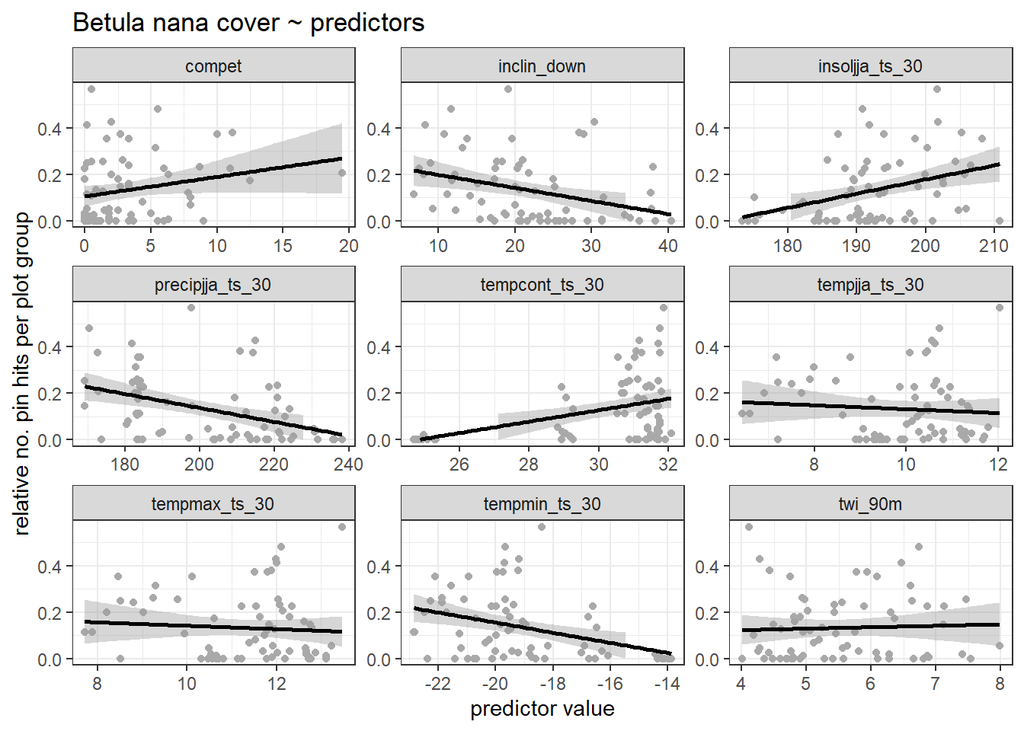

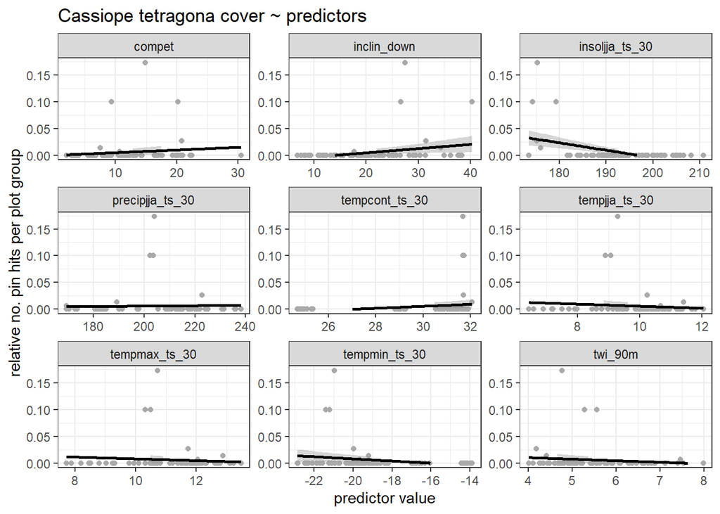

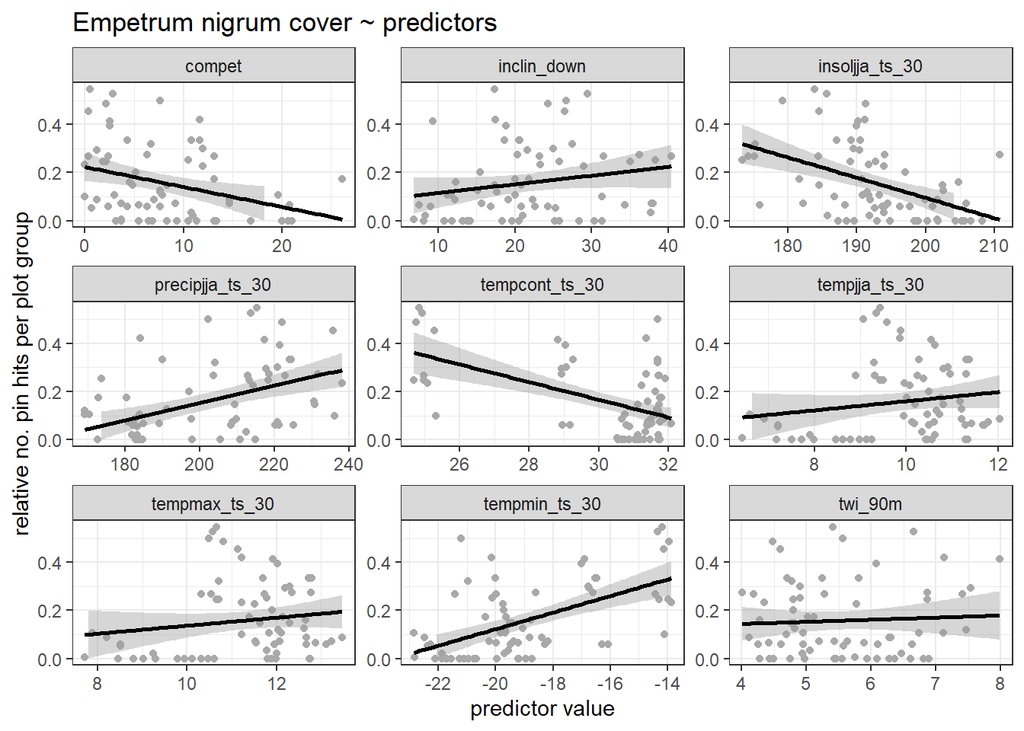

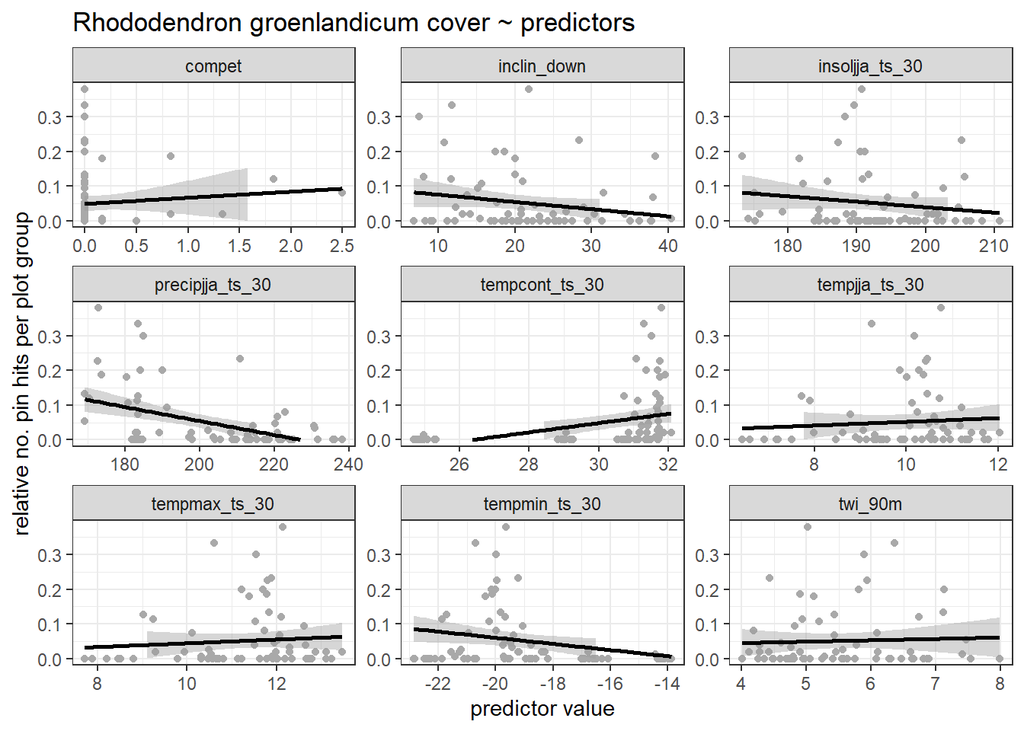

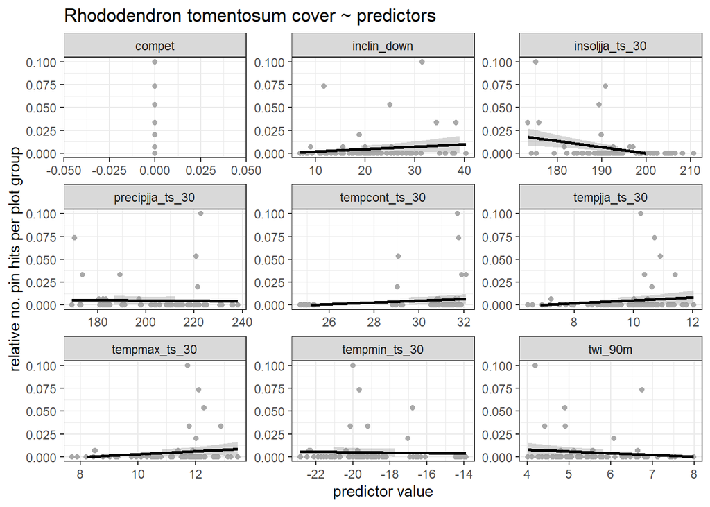

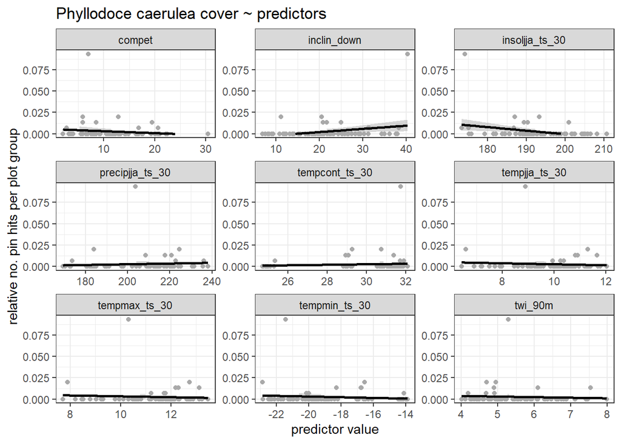

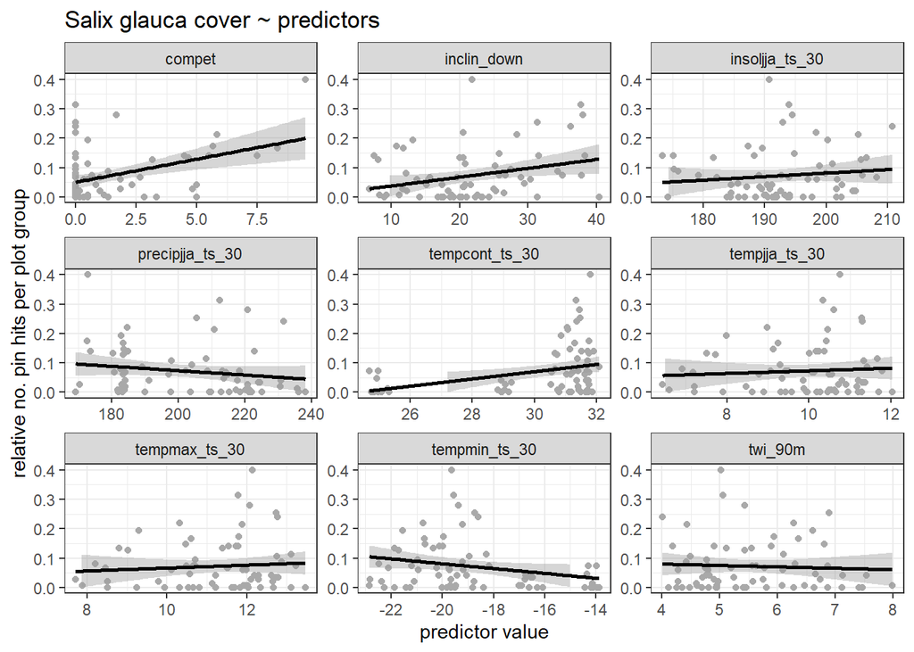

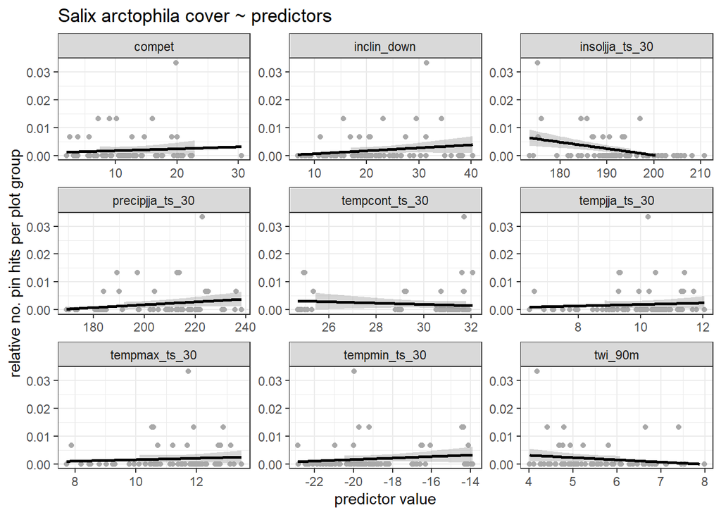

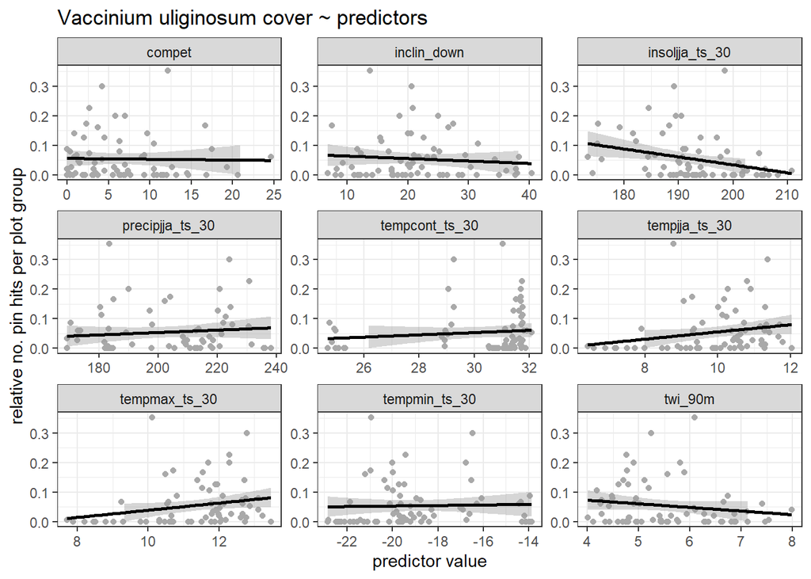

```r
env_cov_bio.long <- env_cov_bio %>%
  select(taxon,
         inclin_down,
         ends_with("ts_30"),
         twi_90m,
         compet,
         cover) %>%
  # pivot to long format
  pivot_longer(cols = c(inclin_down,
                           ends_with("ts_30"),
                           twi_90m,
                           compet),
               names_to = "predictor",
               values_to = "pred_value")

# build function
pred.plot.grid <- function(df){

  taxa <- df %>% pull(taxon) %>% unique() %>% as.character()

  for(taxon_nr in 1:length(taxa)){
    plot <- ggplot(data = df %>% filter(taxon == taxa[taxon_nr]),
                   aes(y = cover, group = taxon)) +
      geom_point(aes(x = pred_value), colour = "darkgrey") +
      geom_smooth(aes(x = pred_value), method = "lm", colour = "black", se = TRUE) +
      facet_wrap(~predictor, scales = "free", ncol = 3) +
      scale_y_continuous("relative no. pin hits per plot group",
                         limits = c(0, max(df %>%
                                             filter(taxon == taxa[taxon_nr]) %>%
                                             pull(cover)))) +
      labs(x = "predictor value") +
      ggtitle(paste0(taxa[taxon_nr], " cover ~ predictors")) +
      theme_bw() +
      theme(legend.position = "none")
    print(plot)
  }
}

# run
pred.plot.grid(env_cov_bio.long)
```

## Multi-species model

### Prepare data for JAGS model

### a) Abundance check & selection of taxa

Only taxa with competition data were included, i.e.

```r
tibble(levels(env_cov_bio_sub$taxon))
```

| levels(env_cov_bio_sub$taxon) |
| --- |
| Betula nana |
| Cassiope tetragona |
| Empetrum nigrum |
| Phyllodoce caerulea |
| Rhododendron groenlandicum |
| Rhododendron tomentosum |
| Salix arctophila |
| Salix glauca |
| Vaccinium uliginosum |

Some of the target taxa showed low abundance for most of the plot groups:

```r
# Summary of zeros per taxon & as percentage of all 69 plotgroups:
env_cov_bio_sub %>% group_by(taxon) %>%
  summarise_at(vars(cover), list(~sum(. == 0))) %>%
  rename(zeros = cover) %>%
  mutate(zeros_perc = zeros/69) %>%
  arrange(desc(zeros))
```

| taxon | zeros | zeros_perc |
| --- | --- | --- |
| Cassiope tetragona | 63 | 0.9130435 |
| Phyllodoce caerulea | 60 | 0.8695652 |
| Rhododendron tomentosum | 59 | 0.8550725 |
| Salix arctophila | 57 | 0.8260870 |
| Rhododendron groenlandicum | 35 | 0.5072464 |
| Vaccinium uliginosum | 25 | 0.3623188 |
| Salix glauca | 18 | 0.2608696 |
| Betula nana | 17 | 0.2463768 |
| Empetrum nigrum | 15 | 0.2173913 |

To improve the chance of model convergence, we removed *Cassiope tetragona* & *Phyllodoce caerulea* (moving down the list):

```r
env_cov_bio_sub <- env_cov_bio_sub[env_cov_bio_sub$taxon %in% c("Cassiope tetragona",
                                                                "Phyllodoce caerulea")==F,] %>%
  droplevels(env_cov_bio_sub$taxon)
head(env_cov_bio_sub, nlevels(env_cov_bio_sub$taxon))
```

|  | site_alt_plotgroup_id | site | site_alt_id | year | long | lat | tempjja_ts_10 | tempmax_ts_10 | tempmin_ts_10 | tempcont_ts_10 | precipjja_ts_10 | insoljja_ts_10 | inclin_down | twi_90m | taxon | cover | compet |
| --- | --- | --- | --- | --- | --- | --- | --- | --- | --- | --- | --- | --- | --- | --- | --- | --- | --- |
| 1 | 1_100_1 | 1 | 1_100 | 2011 | -51.80355 | 64.23418 | 10.22318 | 11.34972 | -11.97173 | 23.32146 | 163.0041 | 183.7853 | 17.33333 | 5.413612 | Betula nana | 0.0000000 | 0.00000 |
| 3 | 1_100_1 | 1 | 1_100 | 2011 | -51.80355 | 64.23418 | 10.22318 | 11.34972 | -11.97173 | 23.32146 | 163.0041 | 183.7853 | 17.33333 | 5.413612 | Empetrum nigrum | 0.5466667 | 0.50000 |
| 4 | 1_100_1 | 1 | 1_100 | 2011 | -51.80355 | 64.23418 | 10.22318 | 11.34972 | -11.97173 | 23.32146 | 163.0041 | 183.7853 | 17.33333 | 5.413612 | Rhododendron groenlandicum | 0.0000000 | 0.00000 |
| 5 | 1_100_1 | 1 | 1_100 | 2011 | -51.80355 | 64.23418 | 10.22318 | 11.34972 | -11.97173 | 23.32146 | 163.0041 | 183.7853 | 17.33333 | 5.413612 | Rhododendron tomentosum | 0.0000000 | 0.00000 |
| 7 | 1_100_1 | 1 | 1_100 | 2011 | -51.80355 | 64.23418 | 10.22318 | 11.34972 | -11.97173 | 23.32146 | 163.0041 | 183.7853 | 17.33333 | 5.413612 | Salix glauca | 0.0000000 | 0.00000 |
| 8 | 1_100_1 | 1 | 1_100 | 2011 | -51.80355 | 64.23418 | 10.22318 | 11.34972 | -11.97173 | 23.32146 | 163.0041 | 183.7853 | 17.33333 | 5.413612 | Salix arctophila | 0.0000000 | 14.16667 |
| 9 | 1_100_1 | 1 | 1_100 | 2011 | -51.80355 | 64.23418 | 10.22318 | 11.34972 | -11.97173 | 23.32146 | 163.0041 | 183.7853 | 17.33333 | 5.413612 | Vaccinium uliginosum | 0.0200000 | 0.00000 |

### b) adjustion of data structure

Data was ordered by site/altitude/plotgroup and taxon

```r
env_cov_bio_sub <- env_cov_bio_sub[order(env_cov_bio_sub$site_alt_plotgroup_id, env_cov_bio_sub$taxon),]
```

As JAGS is only able to handle numeric input, all variables are assigned a numeric identifier:

```r
env_cov_bio_sub$plotgroup.NUM <- as.numeric(factor(env_cov_bio_sub$site_alt_plotgroup_id, levels=unique(env_cov_bio_sub$site_alt_plotgroup_id)))
env_cov_bio_sub$site.NUM <- as.numeric(factor(env_cov_bio_sub$site, levels = unique(env_cov_bio_sub$site)))
env_cov_bio_sub$taxon.NUM <- as.numeric(factor(env_cov_bio_sub$taxon, levels = unique(env_cov_bio_sub$taxon)))
```

Thus, taxa were coded in alphabetical order as follows:

```r
data.frame(taxon = levels(env_cov_bio_sub$taxon),
                       num = env_cov_bio_sub$taxon.NUM[1:nlevels(env_cov_bio_sub$taxon)])
```

| taxon | num |
| --- | --- |
| Betula nana | 1 |
| Empetrum nigrum | 2 |
| Rhododendron groenlandicum | 3 |
| Rhododendron tomentosum | 4 |
| Salix arctophila | 5 |
| Salix glauca | 6 |
| Vaccinium uliginosum | 7 |

In order to define the level of variation of interest, a unique taxon-plotgroup combination variable was created:

```r
env_cov_bio_sub$taxon_plotgroup <- paste(env_cov_bio_sub$plot.group.name,env_cov_bio_sub$taxon,sep="_")
env_cov_bio_sub$taxon_plotgroup.NUM <- as.numeric(factor(env_cov_bio_sub$taxon_plotgroup, levels = unique(env_cov_bio_sub$taxon_plotgroup)))
```

Numeric predictors were scaled:

```r
num_pred <- env_cov_bio_sub %>% select(ends_with("_ts_10"), matches("sri"),
                                       starts_with("twi"),
                                       matches("compet"))
for(i in 1:length(num_pred)){
  col <- colnames(num_pred[i])
  env_cov_bio_sub[paste0(col,"C")] <- as.numeric(scale(num_pred[i], scale = TRUE, center = TRUE))
}
```

To account for the range of the cover response ($0 \leq cover \leq 1$), the model needs a mixed structure incorporating a beta distribution (for all continuous values with $0 < cover < 1$) and a binomial distribution (for all discrete values of $cover = \{0, 1\}$). An additional variable *cover_discrete* was introduced to separate the dataset into discrete (= 1) and continuous (= 0) cover values:

```r
env_cov_bio_sub$cover_discrete <- ifelse(env_cov_bio_sub$cover == 1 | env_cov_bio_sub$cover == 0, 1, 0)
y.dis <- env_cov_bio_sub[env_cov_bio_sub$cover_discrete == 1,]
y.cont <- env_cov_bio_sub[env_cov_bio_sub$cover_discrete == 0,]
```

### c) assembling data for model input in a list

JAGS needs data input in list format, so I provided all relevant variables as follows:

```r
shrub_gradient_jags.data <- list(
  UV_plotgroup.tot = env_cov_bio_sub$plotgroup.NUM,
  UV_taxon.tot = env_cov_bio_sub$taxon.NUM[!duplicated(env_cov_bio_sub$taxon_plotgroup.NUM)], #one value per tXpg
  N_sites = length(unique(env_cov_bio_sub$site)),
  N_plotgroups = length(unique(env_cov_bio_sub$site_alt_plotgroup_id)),
  N_taxa = length(unique(env_cov_bio_sub$taxon)),
  N_taxonXplotgroup.tot = length(unique(env_cov_bio_sub$taxon_plotgroup.NUM)),

  # discrete data
  cov.dis = y.dis$cover,
  UV_plotgroup.dis = y.dis$plotgroup.NUM,
  # UV_site.dis = y.dis$site.NUM,
  # year.dis = y.dis$year,
  UV_taxon.dis = y.dis$taxon.NUM,
  # sri.dis = y.dis$sriC,
  compet.dis = y.dis$competC,
  N_discrete = nrow(y.dis),
  N_sites.dis = length(unique(y.dis$site)),
  N_plotgroups.dis = length(unique(y.dis$site_alt_plotgroup_id)),
  UV_taxonXplotgroup.dis = y.dis$taxon_plotgroup.NUM,

  # continuous data
  cov.cont = y.cont$cover,
  UV_plotgroup.cont = y.cont$plotgroup.NUM,
  UV_site.cont = y.cont$site.NUM,
  year.cont = y.cont$year,
  UV_taxon.cont = y.cont$taxon.NUM,
  # sri.cont = y.cont$sriC,
  compet.cont = y.cont$competC,
  N_cont = nrow(y.cont),
  N_sites.cont = length(unique(y.cont$site)),
  N_plotgroups.cont = length(unique(y.cont$site_alt_plotgroup_id)),
  UV_taxonXplotgroup.cont = y.cont$taxon_plotgroup.NUM,

  # environmental predictors -> set target predictor name to env.*
  env.tot = env_cov_bio_sub$tempjja_ts_10C[!duplicated(env_cov_bio_sub$plotgroup.NUM)]#, # one value per tXpg, amt = annual mean temperature = bio_1
)
str(shrub_gradient_jags.data)
```

```
## List of 25
##  $ UV_plotgroup.tot       : num [1:483] 1 1 1 1 1 1 1 2 2 2 ...
##  $ UV_taxon.tot           : num [1:7] 1 2 3 4 5 6 7
##  $ N_sites                : int 5
##  $ N_plotgroups           : int 69
##  $ N_taxa                 : int 7
##  $ N_taxonXplotgroup.tot  : int 7
##  $ cov.dis                : num [1:226] 0 0 0 0 0 0 0 0 0 0 ...
##  $ UV_plotgroup.dis       : num [1:226] 1 1 1 1 1 2 2 2 2 2 ...
##  $ UV_taxon.dis           : num [1:226] 1 3 4 5 6 1 3 4 5 7 ...
##  $ compet.dis             : num [1:226] -0.755 -0.755 -0.755 1.649 -0.755 ...
##  $ N_discrete             : int 226
##  $ N_sites.dis            : int 5
##  $ N_plotgroups.dis       : int 66
##  $ UV_taxonXplotgroup.dis : num [1:226] 1 3 4 5 6 1 3 4 5 7 ...
##  $ cov.cont               : num [1:257] 0.5467 0.02 0.2467 0.0733 0.4867 ...
##  $ UV_plotgroup.cont      : num [1:257] 1 1 2 2 3 3 4 4 4 4 ...
##  $ UV_site.cont           : num [1:257] 1 1 1 1 1 1 1 1 1 1 ...
##  $ year.cont              : int [1:257] 2011 2011 2011 2011 2011 2011 2011 2011 2011 2011 ...
##  $ UV_taxon.cont          : num [1:257] 2 7 2 6 2 7 2 5 6 7 ...
##  $ compet.cont            : num [1:257] -0.67 -0.755 -0.444 -0.755 -0.387 ...
##  $ N_cont                 : int 257
##  $ N_sites.cont           : int 5
##  $ N_plotgroups.cont      : int 69
##  $ UV_taxonXplotgroup.cont: num [1:257] 2 7 2 6 2 7 2 5 6 7 ...
##  $ env.tot                : num [1:69] -0.322 -0.277 -0.217 -0.388 -0.417 ...
```

…and specified the model:

```r
write("

  model{

    # priors

        for (i in 1:N_taxa){
          intercept[i] ~ dnorm(0,0.0001) # intercept per taxon instead of site-taxon?
        }

      for (i in 1:N_taxa){   # same level as main effect of interest, i.e. taxon X plotgroup # AB - make this slope per taxon (not taxon-plotgroup?)
        b_compet[i] ~ dnorm(0,0.0001)
        # b_slope[i] ~ dnorm(0,0.0001)
        b_sri[i] ~ dnorm(0,0.0001)
      }

      sigma.taxonXplotgroup~dunif(0,100)
      tau.taxonXplotgroup<-1/(sigma.taxonXplotgroup*sigma.taxonXplotgroup)

      for (i in 1:N_taxa){
        b.env.x[i]~dnorm(0, 0.001)
        b.env.x2[i]~dnorm(0, 0.001)
      }

      phi~dgamma(0.1,0.1)

    # LIKELIHOOD for discrete part

      for (i in 1:N_discrete){
        cov.dis[i] ~ dbern(mu[i])
        logit(mu[i]) <- b_compet[UV_taxon.dis[i]]*compet.dis[i] + # slope per taxon NOT per taxon-plotgroup?
                        # b_slope[UV_taxon.dis[i]]*slope.dis[i] +
                        # b_sri[UV_taxon.dis[i]]*sri.dis[i] +
                        b_taxonXplotgroup[UV_taxonXplotgroup.dis[i]] # beta by taxon X plotgroup combination, iterating over plots
      }


    # LIKELIHOOD for continuous part

      for (i in 1:N_cont){
        cov.cont[i] ~ dbeta(p[i], q[i])
        p[i] <- mu2[i] * phi
        q[i] <- (1 - mu2[i]) * phi
        logit(mu2[i]) <- b_compet[UV_taxon.cont[i]]*compet.cont[i] +
                         # b_slope[UV_taxon.cont[i]]*slope.cont[i] +
                         # b_sri[UV_taxon.cont[i]]*sri.cont[i] +
                         b_taxonXplotgroup[UV_taxonXplotgroup.cont[i]] # beta by taxon X plotgroup combination, iterating over plots
      }

      for (j in 1:N_taxonXplotgroup.tot){ # length of total plotgroup per taxon combinations
        b_taxonXplotgroup[j] ~ dnorm(mu.taxonXplotgroup[j],tau.taxonXplotgroup)
        mu.taxonXplotgroup[j] <- intercept[UV_taxon.tot[j]] + # slope per taxon not site-taxon?
                    b.env.x[UV_taxon.tot[j]]*env.tot[j] +
                    b.env.x2[UV_taxon.tot[j]]*(env.tot[j]^2) # add more plotgroup-level predictors
      }


      }
  ","shrub_gradient.jags")
```

After specifying the parameters to be monitored, the model was run:

```r
params <- c("b.env.x","b.env.x2","intercept","b_compet", "b_sri","b_taxonXplotgroup[1]","b_taxonXplotgroup[2]","b_taxonXplotgroup[3]","b_taxonXplotgroup[483]","sigma.taxonXplotgroup","phi")

# run model
model_out.shrub_gradient <- jags(shrub_gradient_jags.data, inits = NULL, params,
                                 model.file = "shrub_gradient.jags", n.chains = 3,
                                 n.iter = 8000, n.burnin = 6000, n.thin=2, DIC=FALSE,
                                 working.directory=NULL, progress.bar = "text")
```

```
## module glm loaded
```

```
## module dic loaded
```

```
##
##
## Deleting model
```

```
## Error in update.jags(model, n.iter, ...): Can't update. No model!
```

**!!! Model crashes !!!** (JvO 06 Apr / 05 May 20)

$\implies$ re-try with breaking up the model for the separate species

## Single-species models

This dataset is a new one containing predictors extracted from downscaled CHELSA climate data.

Analyses conducted on fusion table at **plot group $\times$ taxon level** (same as above): 621 observations for 57 variables

### Prepare data for JAGS model

### a) selection of variables relevant for analysis

including predictors

- Information on site, plot group, sampling location (lat, lon, altitude), sampling year
- downscaled CHELSA predictors (*[…]_ts_XX*)
- solar radiation index (SRI, following [Keating et al. 2007](http://www.bioone.org/doi/abs/10.2193/2006-359), yet to come), slope (erosion measure) & moisture availability (-> Jakob, yet to come)
- taxon (see above for levels)
- competition pressure in the community (as summed abundance of taller-growing shrub species within a plot, averaged within plot groups)

and response variable

- cover (as relative no. hits per plot, averaged within plot groups)

```r
env_cov_bio_sub <- env_cov_bio %>%
  select(site_alt_plotgroup_id, site, site_alt_id, year, long, lat,  # plot info / metadata
  ends_with("_ts_10"),   # CHELSA predictors averaged over 10-year period prior to study year
  inclin_down, twi_90m, #sri,
  #mean_summ_ndvi_yos, cv_mean_summ_ndvi_2001_to_yos, Perc_dist_coast_lines,   # environmental data
  taxon, cover, compet)   # taxon, cover response, competition pressure
head(env_cov_bio_sub)
```

|  | site_alt_plotgroup_id | site | site_alt_id | year | long | lat | tempjja_ts_10 | tempmax_ts_10 | tempmin_ts_10 | tempcont_ts_10 | precipjja_ts_10 | insoljja_ts_10 | inclin_down | twi_90m | taxon | cover | compet |
| --- | --- | --- | --- | --- | --- | --- | --- | --- | --- | --- | --- | --- | --- | --- | --- | --- | --- |
| 1 | 1_100_1 | 1 | 1_100 | 2011 | -51.80355 | 64.23418 | 10.22318 | 11.34972 | -11.97173 | 23.32146 | 163.0041 | 183.7853 | 17.33333 | 5.413612 | Betula nana | 0.0000000 | 0.00000 |
| 2 | 1_100_1 | 1 | 1_100 | 2011 | -51.80355 | 64.23418 | 10.22318 | 11.34972 | -11.97173 | 23.32146 | 163.0041 | 183.7853 | 17.33333 | 5.413612 | Cassiope tetragona | 0.0000000 | 14.16667 |
| 3 | 1_100_1 | 1 | 1_100 | 2011 | -51.80355 | 64.23418 | 10.22318 | 11.34972 | -11.97173 | 23.32146 | 163.0041 | 183.7853 | 17.33333 | 5.413612 | Empetrum nigrum | 0.5466667 | 0.50000 |
| 4 | 1_100_1 | 1 | 1_100 | 2011 | -51.80355 | 64.23418 | 10.22318 | 11.34972 | -11.97173 | 23.32146 | 163.0041 | 183.7853 | 17.33333 | 5.413612 | Rhododendron groenlandicum | 0.0000000 | 0.00000 |
| 5 | 1_100_1 | 1 | 1_100 | 2011 | -51.80355 | 64.23418 | 10.22318 | 11.34972 | -11.97173 | 23.32146 | 163.0041 | 183.7853 | 17.33333 | 5.413612 | Rhododendron tomentosum | 0.0000000 | 0.00000 |
| 6 | 1_100_1 | 1 | 1_100 | 2011 | -51.80355 | 64.23418 | 10.22318 | 11.34972 | -11.97173 | 23.32146 | 163.0041 | 183.7853 | 17.33333 | 5.413612 | Phyllodoce caerulea | 0.0000000 | 14.16667 |

### b) adjustion of data structure

Data was ordered by site/altitude/plotgroup and taxon

```r
env_cov_bio_sub <- env_cov_bio_sub[order(env_cov_bio_sub$site_alt_plotgroup_id, env_cov_bio_sub$taxon),]
```

As JAGS is only able to handle numeric input, all variables are assigned a numeric identifier:

```r
env_cov_bio_sub$plotgroup.NUM <- as.numeric(factor(env_cov_bio_sub$site_alt_plotgroup_id, levels=unique(env_cov_bio_sub$site_alt_plotgroup_id)))
env_cov_bio_sub$site.NUM <- as.numeric(factor(env_cov_bio_sub$site, levels = unique(env_cov_bio_sub$site)))
env_cov_bio_sub$taxon.NUM <- as.numeric(factor(env_cov_bio_sub$taxon, levels = unique(env_cov_bio_sub$taxon)))
```

Taxa were coded as follows:

```r
data.frame(taxon = levels(env_cov_bio_sub$taxon),
                       num = env_cov_bio_sub$taxon.NUM[1:nlevels(env_cov_bio_sub$taxon)])
```

| taxon | num |
| --- | --- |
| Betula nana | 1 |
| Cassiope tetragona | 2 |
| Empetrum nigrum | 3 |
| Phyllodoce caerulea | 4 |
| Rhododendron groenlandicum | 5 |
| Rhododendron tomentosum | 6 |
| Salix arctophila | 7 |
| Salix glauca | 8 |
| Vaccinium uliginosum | 9 |

Numeric predictors were scaled:

```r
num_pred <- env_cov_bio_sub %>% select(ends_with("_ts_10"), matches("sri"),
                                       starts_with("twi"),
                                       matches("compet"))
for(i in 1:length(num_pred)){
  col <- colnames(num_pred[i])
  env_cov_bio_sub[paste0(col,"C")] <- as.numeric(scale(num_pred[i], scale = TRUE, center = TRUE))
}
```

To account for the range of the cover response ($0 \leq cover \leq 1$), the model needs a mixed structure incorporating a beta distribution (for all continuous values with $0 < cover < 1$) and a binomial distribution (for all discrete values of $cover = \{0, 1\}$). An additional variable *cover_discrete* was introduced to separate the dataset into discrete (= 1) and continuous (= 0) cover values:

```r
env_cov_bio_sub$cover_discrete <- ifelse(env_cov_bio_sub$cover == 1 | env_cov_bio_sub$cover == 0, 1, 0)
```

The dataset was then ready to be split up into the species of interest. As a first trial, I focused on *Betula nana*:

```r
# complete Betula nana data
BetNan.tot <- filter(env_cov_bio_sub, taxon == "Betula nana")
# discrete cover values
BetNan.dis <- filter(BetNan.tot, cover_discrete == 1) # contains only zeros as responses
# continuous cover values
BetNan.cont <- filter(BetNan.tot, cover_discrete == 0)
```

### c) assembling data for model input in a list

JAGS needs data input in list format, so I provided all relevant variables as follows:

```r
shrub_gradient_jags.BetNan.data <- list(
  N_plotgroups = length(unique(BetNan.tot$site_alt_plotgroup_id)),
  cov.dis = BetNan.dis$cover,
  compet.dis = BetNan.dis$competC,
  N_discrete = nrow(BetNan.dis),
  cov.cont = BetNan.cont$cover,
  compet.cont = BetNan.cont$competC,
  N_cont = nrow(BetNan.cont),
  env.tot = BetNan.tot$tempjja_ts_10C[!duplicated(BetNan.tot$plotgroup.NUM)]#, # one value per tXpg, amt = annual mean
)
str(shrub_gradient_jags.BetNan.data)
```

```
## List of 8
##  $ N_plotgroups: int 69
##  $ cov.dis     : num [1:17] 0 0 0 0 0 0 0 0 0 0 ...
##  $ compet.dis  : num [1:17] -0.916 -0.641 -0.916 -0.741 -0.916 ...
##  $ N_discrete  : int 17
##  $ cov.cont    : num [1:52] 0.02 0.0133 0.0333 0.18 0.0267 ...
##  $ compet.cont : num [1:52] -0.866 -0.641 -0.916 -0.542 -0.816 ...
##  $ N_cont      : int 52
##  $ env.tot     : num [1:69] -0.322 -0.277 -0.217 -0.388 -0.417 ...
```

…and specified the model:

```r
write("

  model{

    # priors

      intercept ~ dnorm(0, 0.0001)

      b_compet ~ dnorm(0, 0.0001)
      # b_sri ~ dnorm(0, 0.0001)
      # b_slope ~ dnorm(0, 0.0001)

      sigma.plotgroup ~ dunif(0,100)
      tau.plotgroup <- 1/(sigma.plotgroup * sigma.plotgroup)

      b.env.x ~ dnorm(0, 0.001)
      b.env.x2 ~ dnorm(0, 0.001)

      phi ~ dgamma(0.1, 0.1)


    # LIKELIHOOD for discrete part

      for (i in 1:N_discrete){
        cov.dis[i] ~ dbern(mu[i])
        logit(mu[i]) <- b_compet*compet.dis[i] #+ # slope per taxon NOT per taxon-plotgroup?
                        # b_slope[i]*slope.dis[i] +
                        # b_sri[i]*sri.dis[i]
      }


    # LIKELIHOOD for continuous part

      for (i in 1:N_cont){
        cov.cont[i] ~ dbeta(p[i], q[i])
        p[i] <- mu2[i] * phi
        q[i] <- (1 - mu2[i]) * phi
        logit(mu2[i]) <- b_compet*compet.cont[i] #+ # slope per taxon NOT per taxon-plotgroup?
                        # b_slope[i]*slope.cont[i] +
                        # b_sri[i]*sri.cont[i]
      }

      for (j in 1:N_plotgroups){ # length of total plotgroups
        b_plotgroup[j] ~ dnorm(mu.plotgroup[j],tau.plotgroup)
        mu.plotgroup[j] <- intercept + # slope per taxon not site-taxon?
                    b.env.x * env.tot[j] +
                    b.env.x2 * (env.tot[j]^2) # add more plotgroup-level predictors
      }

      }
  ","shrub_gradient.BetNan.jags")
```

After specifying the parameters to be monitored, the model was run:

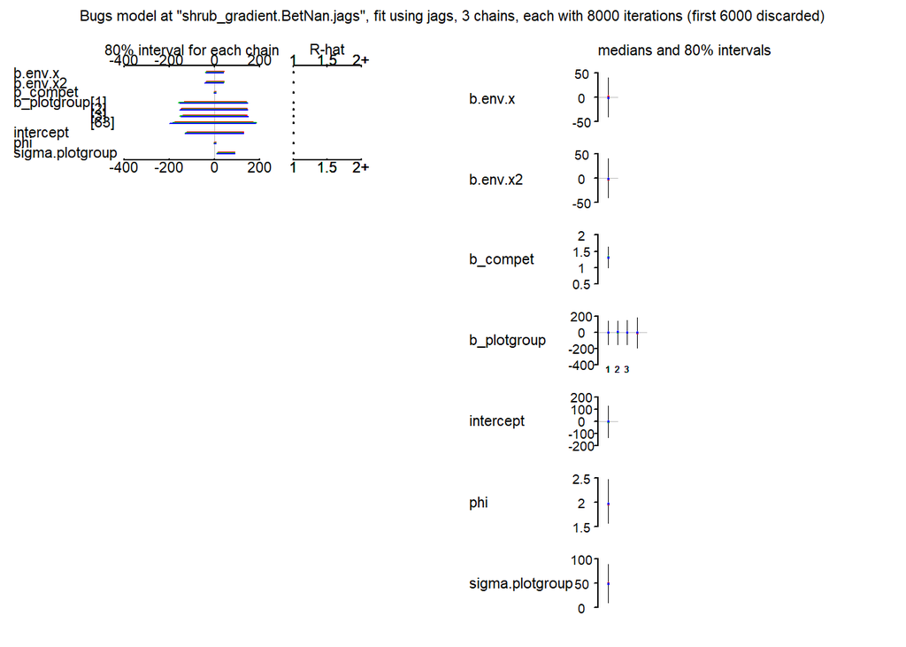

```r
params <- c("b.env.x","b.env.x2","intercept","b_compet", "b_sri","b_plotgroup[1]","b_plotgroup[2]","b_plotgroup[3]","b_plotgroup[63]","sigma.plotgroup","phi")

# run model
model_out.shrub_gradient.BetNan <- jags(shrub_gradient_jags.BetNan.data, inits = NULL, params,
                                 model.file = "shrub_gradient.BetNan.jags", n.chains = 3,
                                 n.iter = 8000, n.burnin = 6000, n.thin=2, DIC=FALSE,
                                 working.directory=NULL, progress.bar = "text")
plot(model_out.shrub_gradient.BetNan) #check convergence, etc.
```

[repeat with 0 filtered out]